# San Francisco Pedestrian Safety Review

Laura Ye

December 17, 2017

## Overview

The city of San Francisco has many public datasets involving city infrastructure, crime, housing, environment, etc. In my project, I aim to use a few (detailed below) to visualize the typical safety of a pedestrian in the city of San Francisco. I will combine data from location of stop signs and traffic signals to cases opened and also police department incidents to determine the likelihood of an accident involving a pedestrian for each intersection.

## Data Sources

Data sources were obtained from [DataSF](https://data.sfgov.org) which has a lot of data sets concerning San Francisco.

[311 Cases](https://data.sfgov.org/City-Infrastructure/311-Cases/vw6y-z8j6)

[Estimated Yearly Pedestrian Volume at Intersections](https://data.sfgov.org/Transportation/Estimated-Yearly-Pedestrian-Volume-at-Intersection/v62e-2jxp)

[Stop Signs](https://data.sfgov.org/Transportation/Stop-Signs/wmdf-5y3x)

[Traffic Signals](https://data.sfgov.org/Transportation/Traffic-Signals/inpn-273m)

[Police Department Incidents](https://data.sfgov.org/Public-Safety/Police-Department-Incidents/tmnf-yvry)

[Historic Police Districts (Shape files)](https://data.sfgov.org/Public-Safety/Historical-Police-Districts/embj-38bg/data)

## Class Topics Used

- Data wrangling and joining using dplyr
- Exploratory Data Analysis
- Visualizing geospatial data and mapping
- Shiny

## Import Data

Let’s start by importing data from the data sources mentioned above.

```r
library(readr)
cases_311 <- read_csv("311_Cases.csv")
incidents <- read_csv("Police_Department_Incidents.csv")
ped_traffic <- read_csv("Estimated_Yearly_Pedestrian_Volume_at_Intersections.csv")
stop_signs <- read_csv("Stop_Signs.csv")
traffic_signals <- read_csv("Traffic_Signals.csv")
```

## Tidy Data

First, let’s convert the column names to snake case, so that their formats are consistent.

```r
source("fix_column_names.R")
cases_311 <- fix_column_names(cases_311)
incidents <- fix_column_names(incidents)
ped_traffic <- fix_column_names(ped_traffic)
stop_signs <- fix_column_names(stop_signs)
traffic_signals <- fix_column_names(traffic_signals)
```

Then, we want to go through each dataset to extract relevant rows and columns, and cast them into the correct format.

Starting with the 311 cases, we want to filter the category, request_type and request_details column for keywords related to sidewalk, curb, street, construction, pedestrian, sign, encampment. We also only want to keep several useful columns instead of all 19 columns.

```r
library(dplyr)
library(lubridate)

keywords <- paste("sidewalk", "curb", "street", "construction", "pedestrian", "sign", "encampment", sep="|")
cases_311_clean <- cases_311 %>%
  select(case_id, opened, category, request_type, request_details, police_district, latitude, longitude) %>%
  rename(id=case_id, date=opened, descript=request_details) %>%
  filter(grepl(keywords, category, ignore.case=TRUE) |
           grepl(keywords, request_type, ignore.case=TRUE) |
           grepl(keywords, descript, ignore.case=TRUE)) %>%
  mutate(date=mdy(substring(date, first = 1, last = 10))) %>%
  glimpse
```

```
Observations: 1,231,004
Variables: 8
$ id              <int> 241459, 241571, 241917, 241941, 245369, 246589...
$ date            <date> 2008-07-02, 2008-07-02, 2008-07-03, 2008-07-0...
$ category        <chr> "Tree Maintenance", "Tree Maintenance", "Stree...
$ request_type    <chr> "Trees - Damaging_Property", "Trees - Overgrow...
$ descript        <chr> "Lifted_sidewalk_tree_roots", "Blocking_street...
$ police_district <chr> "NORTHERN", "RICHMOND", "SOUTHERN", "NORTHERN"...
$ latitude        <dbl> 37.80493, 37.78120, 37.78361, 37.78574, 37.755...
$ longitude       <dbl> -122.4381, -122.4650, -122.3898, -122.4323, -1...
```

Let’s do something similar incidents as well.

```r
incidents_clean <- incidents %>%
  select(incidnt_num, date, category, descript, pd_district, x, y) %>%
  rename(id=incidnt_num, police_district=pd_district, longitude=x, latitude=y) %>%
  filter(grepl(keywords, category, ignore.case=TRUE) |
           grepl(keywords, descript, ignore.case=TRUE)) %>%
  mutate(date = mdy(date)) %>%
  glimpse
```

```
Observations: 46,486
Variables: 7
$ id              <int> 150098414, 160831113, 150098771, 150098997, 15...
$ date            <date> 2015-02-01, 2016-10-12, 2015-01-29, 2015-02-0...
$ category        <chr> "ROBBERY", "OTHER OFFENSES", "ROBBERY", "ROBBE...
$ descript        <chr> "ROBBERY ON THE STREET, STRONGARM", "OBSTRUCTI...
$ police_district <chr> "CENTRAL", "TENDERLOIN", "MISSION", "SOUTHERN"...
$ longitude       <dbl> -122.4068, -122.4151, -122.4197, -122.4039, -1...
$ latitude        <dbl> 37.79690, 37.78367, 37.76505, 37.78712, 37.751...
```

We can combine 311 cases and Police Department Incidents into one table called events.

```r
events <- full_join(incidents_clean, cases_311_clean) %>%
  mutate(police_district = as.factor(police_district),
         category = as.factor(category)) %>%
  glimpse
```

```
Observations: 1,277,490
Variables: 8
$ id              <int> 150098414, 160831113, 150098771, 150098997, 15...
$ date            <date> 2015-02-01, 2016-10-12, 2015-01-29, 2015-02-0...
$ category        <fctr> ROBBERY, OTHER OFFENSES, ROBBERY, ROBBERY, RO...
$ descript        <chr> "ROBBERY ON THE STREET, STRONGARM", "OBSTRUCTI...
$ police_district <fctr> CENTRAL, TENDERLOIN, MISSION, SOUTHERN, MISSI...
$ longitude       <dbl> -122.4068, -122.4151, -122.4197, -122.4039, -1...
$ latitude        <dbl> 37.79690, 37.78367, 37.76505, 37.78712, 37.751...
$ request_type    <chr> NA, NA, NA, NA, NA, NA, NA, NA, NA, NA, NA, NA...
```

Now let’s shift gears and extract relevant data for Estimated Annual Pedestrian Volume, Stop Signs, and Traffic Signs.

For Annual Pedestrian Volume, we need to extract longitude and latitude, and also the estimated volume.

```r
library(tidyr)
ped_traffic_clean <- ped_traffic %>%
  select(annual_pedestrian_volume, geom) %>%
  extract(geom,
          into=c("latitude", "longitude"),
          "(-?[0-9]*.[0-9]*),{1} {1}(-?[0-9]*.[0-9]*)",
          remove=TRUE) %>%
  mutate(longitude=as.numeric(longitude), latitude=as.numeric(latitude)) %>%
  glimpse
```

```
Observations: 8,135
Variables: 3
$ annual_pedestrian_volume <int> 336571, 230736, 303043, 237005, 19037...
$ latitude                 <dbl> 37.71087, 37.71024, 37.71021, 37.7112...
$ longitude                <dbl> -122.4123, -122.4519, -122.4546, -122...
```

For stop signs, all we need is to extract the longitude and latitude.

```r
stop_signs_clean <- stop_signs %>%
  select(geom) %>%
  extract(geom,
          into=c("latitude", "longitude"),
          "(-?[0-9]*.[0-9]*),{1} {1}(-?[0-9]*.[0-9]*)",
          remove=TRUE) %>%
  mutate(longitude=as.numeric(longitude), latitude=as.numeric(latitude)) %>%
  glimpse
```

```
Observations: 10,323
Variables: 2
$ latitude  <dbl> 37.74076, 37.75110, 37.75110, 37.75129, 37.75120, 37...
$ longitude <dbl> -122.4852, -122.5053, -122.5053, -122.5010, -122.503...
```

For traffic signals, all we need is to extract the longitude and latitude.

```r
traffic_signals_clean <- traffic_signals %>%
  select(geom) %>%
  extract(geom,
          into=c("latitude", "longitude"),
          "(-?[0-9]*.[0-9]*),{1} {1}(-?[0-9]*.[0-9]*)",
          remove=TRUE) %>%
  mutate(longitude=as.numeric(longitude), latitude=as.numeric(latitude)) %>%
  glimpse
```

```
Observations: 1,374
Variables: 2
$ latitude  <dbl> 37.73991, 37.71416, 37.77631, 37.78690, 37.78623, 37...
$ longitude <dbl> -122.3828, -122.4755, -122.3900, -122.3888, -122.389...
```

## Exploratory Data Analysis

### Annual Pedestrian Volume

Summary of Annual Pedestrian Volume

```r
summary(ped_traffic$annual_pedestrian_volume)
```

```
    Min.  1st Qu.   Median     Mean  3rd Qu.     Max.
     646   169740   313329  1247018   837432 45678172
```

Quantiles of Annual Pedestrian Volume

```r
quantile(ped_traffic$annual_pedestrian_volume, probs = seq(0, 1, .1), na.rm = TRUE)
```

```
        0%        10%        20%        30%        40%        50%
     646.0    87849.0   144674.0   198330.4   254732.2   313329.0
       60%        70%        80%        90%       100%
  378834.8   579267.2  1257402.8  2695628.0 45678172.0
```

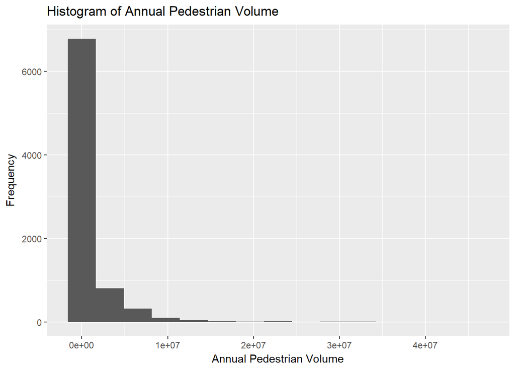

```r
library(ggplot2)
ggplot(ped_traffic_clean, aes(annual_pedestrian_volume)) +
  geom_histogram(bins = 15) +
  xlab("Annual Pedestrian Volume") +
  ylab("Frequency") +
  ggtitle("Histogram of Annual Pedestrian Volume")
```

Visualization of Annual Pedestrian Volume

```r
library(leaflet)
library(RColorBrewer)

pal <- colorNumeric(
  palette = "Reds",
  domain=ped_traffic_clean$annual_pedestrian_volume
)
leaflet(ped_traffic_clean) %>%
  setView(lng = -122.4194, lat = 37.7749, zoom = 12) %>%
  addProviderTiles(providers$CartoDB.Positron) %>%
  addCircles(color=~pal(annual_pedestrian_volume)) %>%
  addLegend(position = "bottomright", pal = pal, values = ~annual_pedestrian_volume,
            title = "Annual Pedestrian Volume", opacity=1)
```

[interactive chart not shown]

We see a rise in pedestrian volume near Financial District and Union Square, as well as along Mission Street, which is accessible via BART.

### Events (Police Incidents and 311 Cases)

Summary of `events` by `police_district`

```r
summary(events$police_district)
```

```
8TH CONGRESSIONAL DISTRICT                    BAYVIEW
                         3                     119611
                   CENTRAL                  INGLESIDE
                    138131                     138347
                   MISSION                   NORTHERN
                    233414                     134352
                      PARK                   RICHMOND
                     88067                      92458
                  SOUTHERN                    TARAVAL
                    126948                     108295
                TENDERLOIN                       NA's
                     46694                      51170
```

Summary of `events` by `category`

```r
summary(events$category)
```

```
        311 External Request            Abandoned Vehicle
                         564                           40
  Blocked Street or SideWalk                     BURGLARY
                       20568                        11531
                  Color Curb    Construction Zone Permits
                       14213                        12782
            Damaged Property       DPW Volunteer Programs
                       14741                          531
                 Encampments        General Request - DPT
                       97033                          220
       General Request - MTA                     Graffiti
                        7836                        76180
            Illegal Postings                    KB Events
                        3561                          435
               MUNI Feedback                 Noise Report
                        6387                         2390
                NON-CRIMINAL               OTHER OFFENSES
                        5413                         1906
       Rec and Park Requests Residential Building Request
                        1641                          435
                     ROBBERY                 Sewer Issues
                       26712                         9293
            Sidewalk or Curb                  Sign Repair
                       34959                        41860
Street and Sidewalk Cleaning               Street Defects
                      739680                        52593
                Streetlights       Temporary Sign Request
                       62483                        21049
            Tree Maintenance                    VANDALISM
                        9530                          924
```

Top 10 Categories

```r
events %>% group_by(category) %>%
  summarize(count=n()) %>%
  arrange(desc(count)) %>%
  top_n(10, count)
```

```
# A tibble: 10 x 2
                       category  count
                         <fctr>  <int>
 1 Street and Sidewalk Cleaning 739680
 2                  Encampments  97033
 3                     Graffiti  76180
 4                 Streetlights  62483
 5               Street Defects  52593
 6                  Sign Repair  41860
 7             Sidewalk or Curb  34959
 8                      ROBBERY  26712
 9       Temporary Sign Request  21049
10   Blocked Street or SideWalk  20568
```

Top 10 Police Districts

```r
events%>%group_by(police_district) %>%
  summarize(count=n()) %>%
  arrange(desc(count)) %>%
  top_n(10, count)
```

```
# A tibble: 10 x 2
   police_district  count
            <fctr>  <int>
 1         MISSION 233414
 2       INGLESIDE 138347
 3         CENTRAL 138131
 4        NORTHERN 134352
 5        SOUTHERN 126948
 6         BAYVIEW 119611
 7         TARAVAL 108295
 8        RICHMOND  92458
 9            PARK  88067
10              NA  51170
```

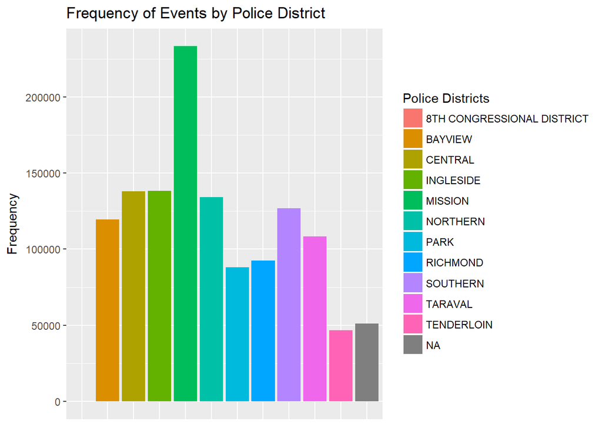

```r
ggplot(events, aes(stat="count", x=police_district, fill=police_district)) +
  geom_bar() +
  xlab("Police District") +
  ylab("Frequency") +
  ggtitle("Frequency of Events by Police District") +
  theme(axis.title.x=element_blank(),
        axis.text.x=element_blank(),
        axis.ticks.x=element_blank()) +
  guides(fill=guide_legend(title="Police Districts"))
```

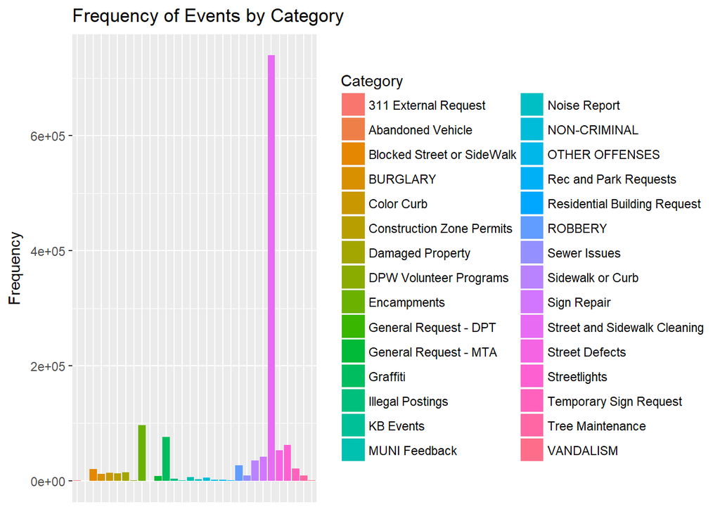

```r
ggplot(events, aes(stat="count", x=category, fill=category)) +
  geom_bar() +
  xlab("Category") +
  ylab("Frequency") +
  ggtitle("Frequency of Events by Category") +
  theme(axis.title.x=element_blank(),
        axis.text.x=element_blank(),
        axis.ticks.x=element_blank()) +
  guides(fill=guide_legend(title="Category"))
```

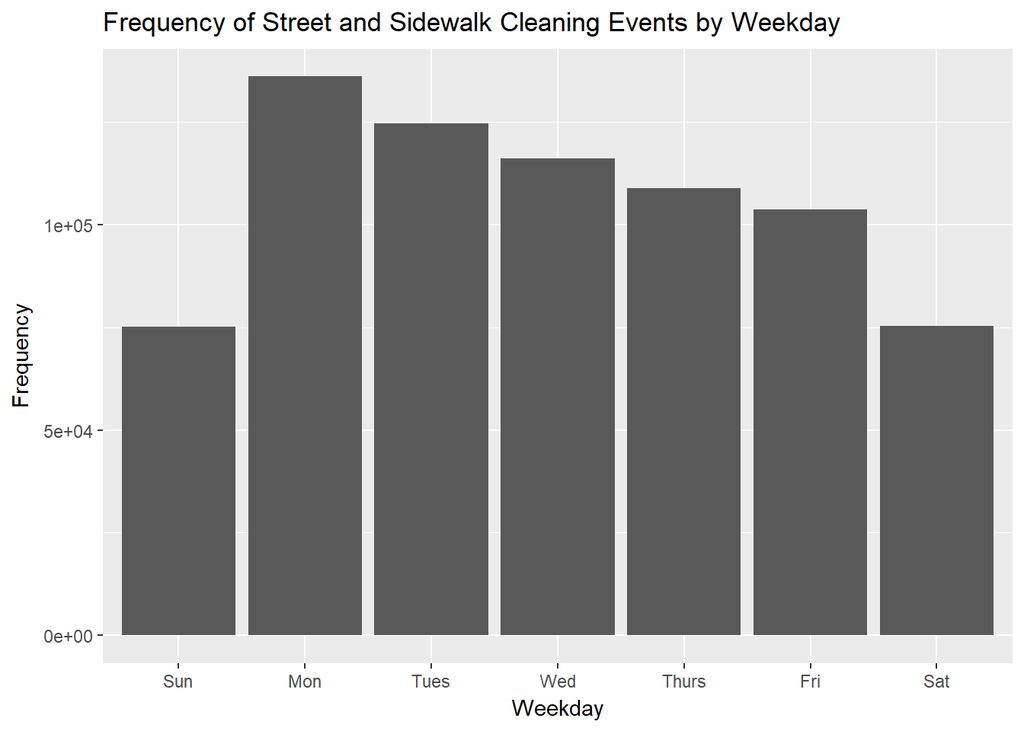

```r
ggplot(events %>% filter(category=="Street and Sidewalk Cleaning"), aes(stat="count", x=wday(date, label=TRUE))) +
  geom_bar() +
  xlab("Weekday") +
  ylab("Frequency") +
  ggtitle("Frequency of Street and Sidewalk Cleaning Events by Weekday")
```

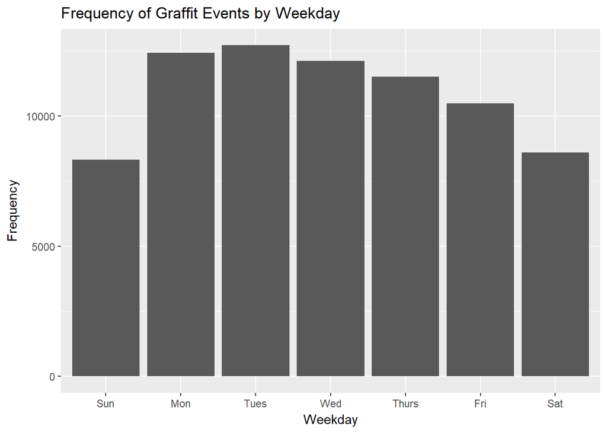

```r
ggplot(events %>% filter(category=="Graffiti"), aes(stat="count", x=wday(date, label=TRUE))) +
  geom_bar() +
  xlab("Weekday") +
  ylab("Frequency") +
  ggtitle("Frequency of Graffit Events by Weekday")
```

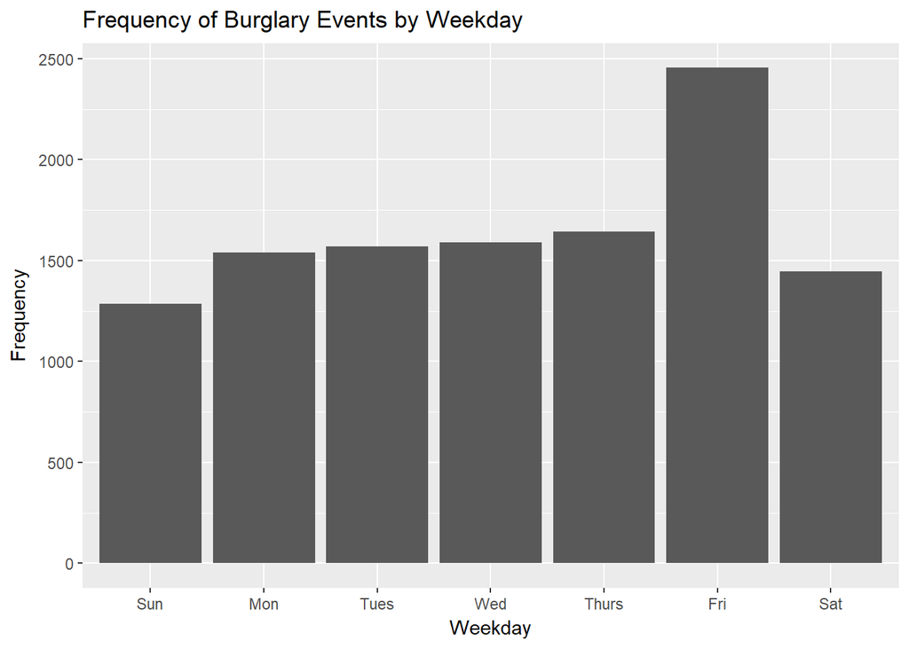

```r
ggplot(events %>% filter(category=="BURGLARY"), aes(stat="count", x=wday(date, label=TRUE))) +
  geom_bar() +
  xlab("Weekday") +
  ylab("Frequency") +
  ggtitle("Frequency of Burglary Events by Weekday")
```

### Stop Signs and Traffic Signals

Map of locations of all the stop signs

```r
stop_icon <- makeIcon(
  iconUrl = "stop_icon.png",
  iconWidth = 30, iconHeight = 24
)

leaflet() %>%
  addProviderTiles(providers$CartoDB.Positron) %>%
  setView(lng = -122.4194, lat = 37.7749, zoom = 12) %>%
  addMarkers(data = stop_signs_clean, icon = stop_icon, clusterOptions = markerClusterOptions())
```

[interactive chart not shown]

Map of locations of all the traffic signals

```r
traffic_icon <- makeIcon(
  iconUrl = "traffic_icon.png",
  iconWidth = 30, iconHeight = 24
)

leaflet() %>%
  addProviderTiles(providers$CartoDB.Positron) %>%
  setView(lng = -122.4194, lat = 37.7749, zoom = 12) %>%
  addMarkers(data = traffic_signals_clean, icon = traffic_icon, clusterOptions = markerClusterOptions())
```

[interactive chart not shown]

## Visualizing geospatial data and mapping

To start, let’s import shapefiles of the police districts to help us visualize the data by police district. I am also going to colorize each police ditrict based on the number of events they have had.

```r
library(rgdal)
library(spdplyr)

pd <- readOGR(dsn = "./Historical Police Districts.geojson",
                  layer = "Historical Police Districts", verbose = FALSE)

pd@data <- pd@data %>% fix_column_names
```

Before colorizing, we need to join the number of events by each district with the shape file so that each polygon can be associated with number of events.

```r
df <- events %>% group_by(police_district) %>%
  summarise(total = n()) %>% rename(district=police_district)

pd@data <- left_join(pd@data, df) %>% glimpse
```

```
Observations: 10
Variables: 4
$ district <chr> "CENTRAL", "SOUTHERN", "BAYVIEW", "MISSION", "PARK", ...
$ company  <fctr> A, B, C, D, F, G, H, I, E, J
$ objectid <fctr> 1, 2, 3, 4, 5, 6, 7, 8, 9, 10
$ total    <int> 138131, 126948, 119611, 233414, 88067, 92458, 138347,...
```

```r
bins <- seq(from=0,to=round(max(pd@data$total)), by=max(pd@data$total)/9)
pal <- colorBin("Greens", domain = pd@data$total, bins = bins)

m <- leaflet(width="100%") %>%
  addProviderTiles(providers$CartoDB.Positron) %>%
  setView(lng = -122.4194, lat = 37.7749, zoom = 12) %>%
  addPolygons(
  data=pd,
  fillColor = pal(pd@data$total),
  weight = 1,
  opacity = 0.5,
  color = "black",
  dashArray = "3",
  fillOpacity = 0.5,
  popup = paste(pd@data$district, " : ", pd@data$total, "Events", sep=" "),
  highlight = highlightOptions(
    weight = 5,
    color = "#666",
    dashArray = "",
    fillOpacity = 0.5,
    bringToFront = FALSE)) %>%

  #Add a legend
  addLegend(pal = pal,
            values = pd@data$total,
            opacity = 0.7,
            title = "Total Events",
            position = "bottomleft")
m
```

[interactive chart not shown]

Let’s add annual pedestrian volume to the map.

```r
pal_ped <- colorNumeric(
  palette = "Reds",
  domain=ped_traffic_clean$annual_pedestrian_volume
)

m <- m %>%
  addCircles(data=ped_traffic_clean,
             lng = ~longitude, lat = ~latitude,
             popup = paste(ped_traffic_clean$annual_pedestrian_volume, "Pedestrians/Year", sep=" "),
             color=~pal_ped(ped_traffic_clean$annual_pedestrian_volume)) %>%
  addLegend(position = "topright", pal = pal_ped, values = ped_traffic_clean$annual_pedestrian_volume,
            title = "Annual Pedestrian Volume", opacity=0.5)
m
```

[interactive chart not shown]

## Shiny

Now that we have a functioning map, let’s take this to Shiny so that we can filter events using the following criteria:

- Date Range
- Category

I attempted to deploy the Shiny app at the webpage below, however, the map does not render because Shiny ran out of memory and I wasn’t able to upgrade to the basic plan or higher. The app does run successfully locally.

https://yelaura.shinyapps.io/sf_pedestrians/

Here is the source code for the Shiny app.

`server.R`

```r
library(shiny)
library(leaflet)
library(readr)
library(dplyr)
library(lubridate)
library(tidyr)
library(rgdal)
library(spdplyr)

cases_311 <- read_csv("311_Cases.csv")
incidents <- read_csv("Police_Department_Incidents.csv")
ped_traffic <- read_csv("Estimated_Yearly_Pedestrian_Volume_at_Intersections.csv")

source("fix_column_names.R")
cases_311 <- fix_column_names(cases_311)
incidents <- fix_column_names(incidents)
ped_traffic <- fix_column_names(ped_traffic)

keywords <- paste("sidewalk", "curb", "street", "construction", "pedestrian", "sign", "encampment", sep="|")

cases_311_clean <- cases_311 %>%
  select(case_id, opened, category, request_type, request_details, police_district, latitude, longitude) %>%
  rename(id=case_id, date=opened, descript=request_details) %>%
  filter(grepl(keywords, category, ignore.case=TRUE) |
           grepl(keywords, request_type, ignore.case=TRUE) |
           grepl(keywords, descript, ignore.case=TRUE)) %>%
  mutate(date=mdy(substring(date, first = 1, last = 10)))

incidents_clean <- incidents %>%
  select(incidnt_num, date, category, descript, pd_district, x, y) %>%
  rename(id=incidnt_num, police_district=pd_district, longitude=x, latitude=y) %>%
  filter(grepl(keywords, category, ignore.case=TRUE) |
           grepl(keywords, descript, ignore.case=TRUE)) %>%
  mutate(date = mdy(date))

events <- full_join(incidents_clean, cases_311_clean) %>%
  mutate(police_district = as.factor(police_district),
         category = as.factor(category))

ped_traffic_clean <- ped_traffic %>%
  select(annual_pedestrian_volume, geom) %>%
  extract(geom,
          into=c("latitude", "longitude"),
          "(-?[0-9]*.[0-9]*),{1} {1}(-?[0-9]*.[0-9]*)",
          remove=TRUE) %>%
  mutate(longitude=as.numeric(longitude), latitude=as.numeric(latitude)) %>%
  sample_frac(0.8)

pd <- readOGR(dsn = "./Historical Police Districts.geojson",
              layer = "Historical Police Districts", verbose = FALSE)

pd@data <- pd@data %>% fix_column_names

shinyServer(function(input, output) {

  output$showThePlot <- renderLeaflet({
    #filter out events by category and date
    df <- events %>%
      filter(
        category == input$catSelector,
        date >= ymd(input$dateRange[1]) & date <= ymd(input$dateRange[2])
      ) %>%
      group_by(police_district) %>%
      summarise(total = n()) %>%
      rename(district=police_district)

      pd@data <- left_join(pd@data, df)

      pal <- colorNumeric(
        palette = "Greens",
        domain=pd@data$total
      )

      pal_ped <- colorNumeric(
        palette = "Reds",
        domain=ped_traffic_clean$annual_pedestrian_volume
      )

      leaflet() %>%
        addProviderTiles(providers$CartoDB.Positron) %>%
        setView(lng = -122.4194, lat = 37.7749, zoom = 12) %>%
        addCircles(data=ped_traffic_clean,
                   lng = ~longitude, lat = ~latitude,
                   popup = paste(ped_traffic_clean$annual_pedestrian_volume, "Pedestrians/Year", sep=" "),
                   color=~pal_ped(ped_traffic_clean$annual_pedestrian_volume)) %>%
        addLegend(position = "topright", pal = pal_ped, values = ped_traffic_clean$annual_pedestrian_volume,
                  title = "Annual Pedestrian Volume", opacity=0.5) %>%

        addPolygons(
          data=pd,
          fillColor = pal(pd@data$total),
          weight = 1,
          opacity = 0.5,
          color = "black",
          dashArray = "3",
          fillOpacity = 0.5,
          popup = paste(pd@data$district, " : ", pd@data$total, "Events", sep=" "),
          highlight = highlightOptions(
            weight = 5,
            color = "#666",
            dashArray = "",
            fillOpacity = 0.5,
            bringToFront = FALSE)) %>%
        addLegend(pal = pal,
                  values = pd@data$total,
                  opacity = 0.7,
                  title = "Total Events",
                  position = "bottomleft")
    })

  output$catSelector <- renderUI({
    selectInput("catSelector",
                "Choose Category of Events:",
                as.list(levels(events$category)),
                selected = "BURGLARY")
  })

})
```

`ui.R`

```r
library(shiny)
library(leaflet)

shinyUI(fluidPage(

  titlePanel("San Francisco Pedestrian Safety"),
  mainPanel(
    dateRangeInput('dateRange',
                   label = 'Date Range Input: mm/dd/yyyy',
                   start = Sys.Date() - 2 * 365, end = Sys.Date(),
                   separator = " - ",
                   format = "mm/dd/yyyy"
    ),
    uiOutput("catSelector"),
    leafletOutput("showThePlot")
  )
))
```

## Current and Future Applications

This Shiny application can be useful for visualizing pedestrian route information. Pedestrians can use the Shiny app to determine how safe their neighborhood is, based on how many events there were in the past, and also by the amount of foot traffic (pedestrian volume) in the intersections near them.

In future applications, the data sets and techniques used in this project may be used to improve pedestrian walking directions on a map platform. This information may also be useful when buying real estate or apartment-hunting.